## Data analysis

Here I explore the data set in terms of the covariates that are included in the metadata. I am removing any colon samples and also any PSC patients that are assigned as SDPSC (small duct).

### Nancy scores (overall and at each site)

Here I look at the Nancy scores between UC and PSC/UC just to see if there are any major differences in terms of the distribution of inflammation evidence between the groups.

#### PSC/UC vs. UC for overall Nancy score

This looks at whether there is a significant difference in overall Nancy score in UC vs PSC/UC.

|  | 0 | 2 | 4 |
| --- | --- | --- | --- |
| HEALTHY | 0 | 0 | 0 |
| PSC/UC | 8 | 1 | 0 |
| UC | 4 | 4 | 1 |

```
##
##  Fisher's Exact Test for Count Data
##
## data:  as.matrix(summary.nancy)[c("UC", "PSC/UC"), ]
## p-value = 0.1312
## alternative hypothesis: two.sided
```

There is not a significant difference between the groups in terms of overall nancy score.

#### Nancy score at site

```r
nancy.at.site <- data.frame(Disease=metadata$Disease, Nancy.score=metadata$nancy.score.at.site, tissue=metadata$Tissue.location)
summary.nancy.at.site <- table(nancy.at.site)
kable(summary.nancy.at.site)
```

| Disease | Nancy.score | tissue | Freq |
| --- | --- | --- | --- |
| HEALTHY | 0 | Caecum | 0 |
| PSC/UC | 0 | Caecum | 8 |
| UC | 0 | Caecum | 8 |
| HEALTHY | 1 | Caecum | 0 |
| PSC/UC | 1 | Caecum | 0 |
| UC | 1 | Caecum | 0 |
| HEALTHY | 2 | Caecum | 0 |
| PSC/UC | 2 | Caecum | 1 |
| UC | 2 | Caecum | 2 |
| HEALTHY | 4 | Caecum | 0 |
| PSC/UC | 4 | Caecum | 0 |
| UC | 4 | Caecum | 0 |
| HEALTHY | 0 | Ileum | 0 |
| PSC/UC | 0 | Ileum | 8 |
| UC | 0 | Ileum | 7 |
| HEALTHY | 1 | Ileum | 0 |
| PSC/UC | 1 | Ileum | 0 |
| UC | 1 | Ileum | 0 |
| HEALTHY | 2 | Ileum | 0 |
| PSC/UC | 2 | Ileum | 1 |
| UC | 2 | Ileum | 0 |
| HEALTHY | 4 | Ileum | 0 |
| PSC/UC | 4 | Ileum | 0 |
| UC | 4 | Ileum | 0 |
| HEALTHY | 0 | Rectum | 0 |
| PSC/UC | 0 | Rectum | 9 |
| UC | 0 | Rectum | 8 |
| HEALTHY | 1 | Rectum | 0 |
| PSC/UC | 1 | Rectum | 1 |
| UC | 1 | Rectum | 0 |
| HEALTHY | 2 | Rectum | 0 |
| PSC/UC | 2 | Rectum | 0 |
| UC | 2 | Rectum | 1 |
| HEALTHY | 4 | Rectum | 0 |
| PSC/UC | 4 | Rectum | 0 |
| UC | 4 | Rectum | 1 |

```r
# Run fishers test at each site
fisher.test(summary.nancy.at.site[,,"Caecum"][2:3,])
```

```
##
##  Fisher's Exact Test for Count Data
##
## data:  summary.nancy.at.site[, , "Caecum"][2:3, ]
## p-value = 1
## alternative hypothesis: two.sided
```

```r
fisher.test(summary.nancy.at.site[,,"Ileum"][2:3,])
```

```
##
##  Fisher's Exact Test for Count Data
##
## data:  summary.nancy.at.site[, , "Ileum"][2:3, ]
## p-value = 1
## alternative hypothesis: two.sided
```

```r
fisher.test(summary.nancy.at.site[,,"Rectum"][2:3,])
```

```
##
##  Fisher's Exact Test for Count Data
##
## data:  summary.nancy.at.site[, , "Rectum"][2:3, ]
## p-value = 1
## alternative hypothesis: two.sided
```

As expected there isn’t a significant difference in inflammation scores. In fact for the majority of samples it is 0 anyway.

### Principle components analysis

Below I do a simple principle components analysis on log2(counts per million). This will hopefully identify any outlier samples and see some broad relationships between samples.

### Read count summary

From memory there was a sample that was particularly low in terms of read counts. Here I plot the read counts for each sample to see if this is indeed the case.

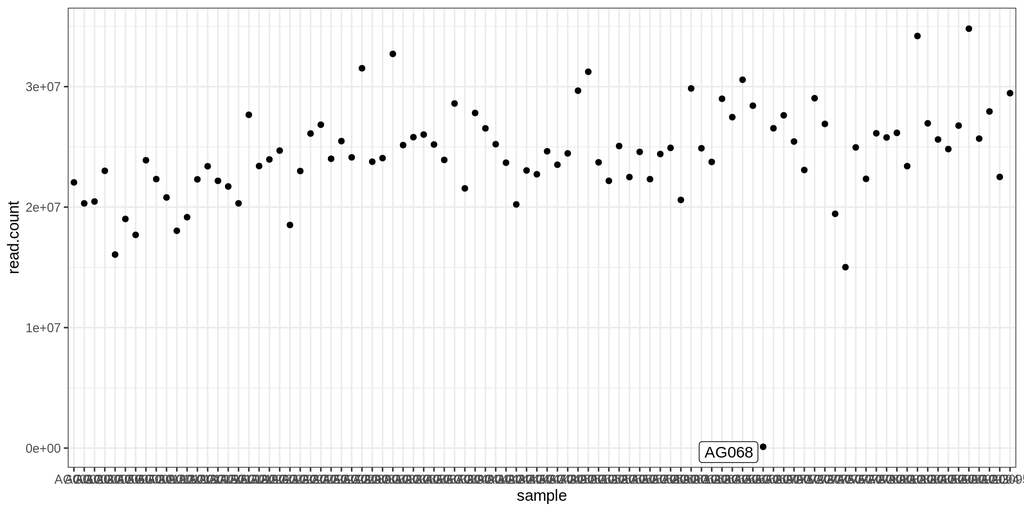

There is a particulary low sample and this should be removed from downstream analysis.

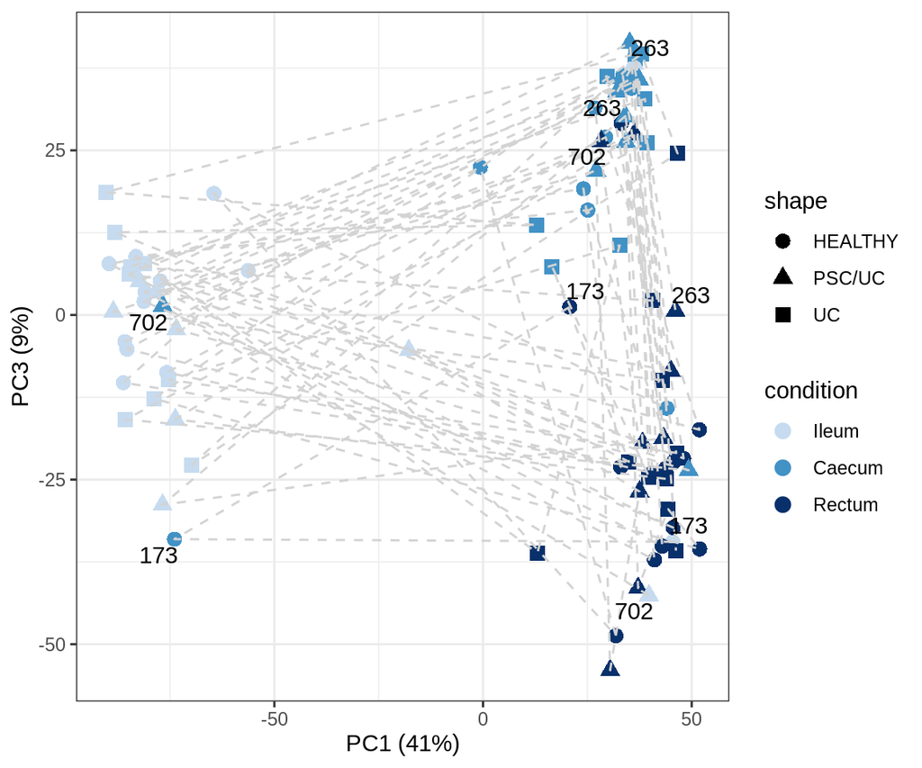

Based on the above PCA there are two options. Either remove the samples that look strange or swap them over for each other. Initially I will remove them as I can’t be 100% certain that they are a sample swap but they also do not fit the patterns that we see between tissues. Samples that are removed for downstream analysis are patient IDS `173, 263, 702`.

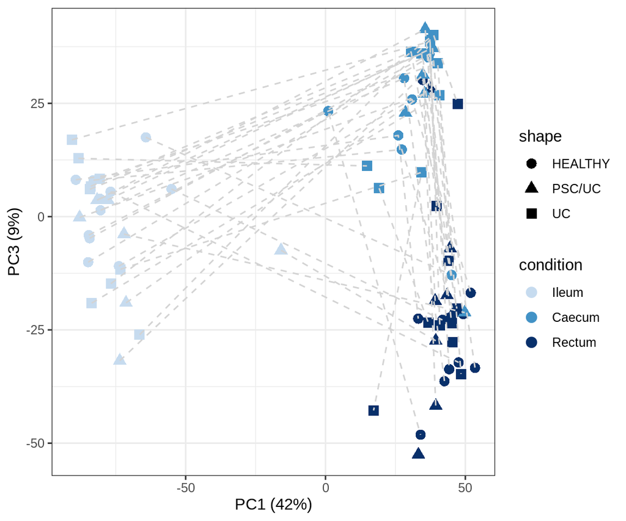

```
##  [1] "R version 3.6.1 (2019-07-05)"
##  [2] "Platform: x86_64-conda_cos6-linux-gnu (64-bit)"
##  [3] "Running under: CentOS release 6.7 (Final)"
##  [4] ""
##  [5] "Matrix products: default"
##  [6] "BLAS/LAPACK: /gfs/devel/nilott/cgat-24102019/conda-install/envs/cgat-flow/lib/libopenblasp-r0.3.9.so"
##  [7] ""
##  [8] "locale:"
##  [9] " [1] LC_CTYPE=en_GB.UTF-8       LC_NUMERIC=C              "
## [10] " [3] LC_TIME=en_GB.UTF-8        LC_COLLATE=en_GB.UTF-8    "
## [11] " [5] LC_MONETARY=en_GB.UTF-8    LC_MESSAGES=en_GB.UTF-8   "
## [12] " [7] LC_PAPER=en_GB.UTF-8       LC_NAME=C                 "
## [13] " [9] LC_ADDRESS=C               LC_TELEPHONE=C            "
## [14] "[11] LC_MEASUREMENT=en_GB.UTF-8 LC_IDENTIFICATION=C       "
## [15] ""
```

[output cut: 60 more lines]